# HEV paper Tables and Figures

Nishan Katuwal & Kristen Aiemjoy

Updated on 2024-06-27

## Table 1: Demographic Characteristics of enrolled individuals

|  | Banepa (N=167) | Dhulikhel (N=85) | Kathmandu (N=401) | Panauti (N=197) | Panchkhal (N=73) | Overall (N=923) |
| --- | --- | --- | --- | --- | --- | --- |
| Age, in years |  |  |  |  |  |  |
| Median (IQR) | 10 ( 5.0 - 17) | 10 ( 5.0 - 15) | 12 ( 6.0 - 18) | 11 ( 5.0 - 17) | 10 ( 6.0 - 16) | 11 ( 6.0 - 17) |
| Min/Max | 1.0 - 27 | 1.0 - 25 | 1.0 - 26 | 1.0 - 27 | 1.0 - 24 | 1.0 - 27 |
| Gender |  |  |  |  |  |  |
| Female | 82 (49.1%) | 41 (48.2%) | 183 (45.6%) | 92 (46.7%) | 33 (45.2%) | 431 (46.7%) |
| Male | 83 (49.7%) | 43 (50.6%) | 214 (53.4%) | 102 (51.8%) | 40 (54.8%) | 482 (52.2%) |
| Missing | 2 (1.2%) | 1 (1.2%) | 4 (1.0%) | 3 (1.5%) | 0 (0%) | 10 (1.1%) |
| Number of study visits |  |  |  |  |  |  |
| Median (IQR) | 3.0 ( 3.0 - 4.0) | 4.0 ( 3.0 - 4.0) | 2.0 ( 1.0 - 3.0) | 3.0 ( 2.0 - 4.0) | 3.0 ( 3.0 - 3.0) | 3.0 ( 2.0 - 3.0) |
| Min/Max | 1.0 - 4.0 | 1.0 - 4.0 | 1.0 - 4.0 | 1.0 - 4.0 | 1.0 - 4.0 | 1.0 - 4.0 |
| Monthly income, Nepalese rupees |  |  |  |  |  |  |
| < 15000 | 11 (6.6%) | 13 (15.3%) | 34 (8.5%) | 30 (15.2%) | 12 (16.4%) | 100 (10.8%) |
| 15000-30000 | 47 (28.1%) | 26 (30.6%) | 116 (28.9%) | 94 (47.7%) | 29 (39.7%) | 312 (33.8%) |
| 30000-50000 | 49 (29.3%) | 23 (27.1%) | 119 (29.7%) | 33 (16.8%) | 13 (17.8%) | 237 (25.7%) |
| >50000 | 17 (10.2%) | 8 (9.4%) | 55 (13.7%) | 9 (4.6%) | 6 (8.2%) | 95 (10.3%) |
| Missing | 43 (25.7%) | 15 (17.6%) | 77 (19.2%) | 31 (15.7%) | 13 (17.8%) | 179 (19.4%) |
| Primary water source |  |  |  |  |  |  |
| Municipal | 88 (52.7%) | 75 (88.2%) | 116 (28.9%) | 34 (17.3%) | 13 (17.8%) | 326 (35.3%) |
| Bottled | 33 (19.8%) | 0 (0%) | 210 (52.4%) | 0 (0%) | 3 (4.1%) | 246 (26.7%) |
| Ground | 5 (3.0%) | 2 (2.4%) | 27 (6.7%) | 55 (27.9%) | 40 (54.8%) | 129 (14.0%) |
| Private | 4 (2.4%) | 0 (0%) | 36 (9.0%) | 0 (0%) | 0 (0%) | 40 (4.3%) |
| Surface | 35 (21.0%) | 7 (8.2%) | 7 (1.7%) | 105 (53.3%) | 17 (23.3%) | 171 (18.5%) |
| Missing | 2 (1.2%) | 1 (1.2%) | 5 (1.2%) | 3 (1.5%) | 0 (0%) | 11 (1.2%) |
| Treat water before drinking |  |  |  |  |  |  |
| No | 65 (38.9%) | 58 (68.2%) | 190 (47.4%) | 109 (55.3%) | 50 (68.5%) | 472 (51.1%) |
| Yes | 100 (59.9%) | 26 (30.6%) | 206 (51.4%) | 85 (43.1%) | 23 (31.5%) | 440 (47.7%) |
| Missing | 2 (1.2%) | 1 (1.2%) | 5 (1.2%) | 3 (1.5%) | 0 (0%) | 11 (1.2%) |

## Figure 1: Identifying the cutoff value for ELISA optical density (OD) responses

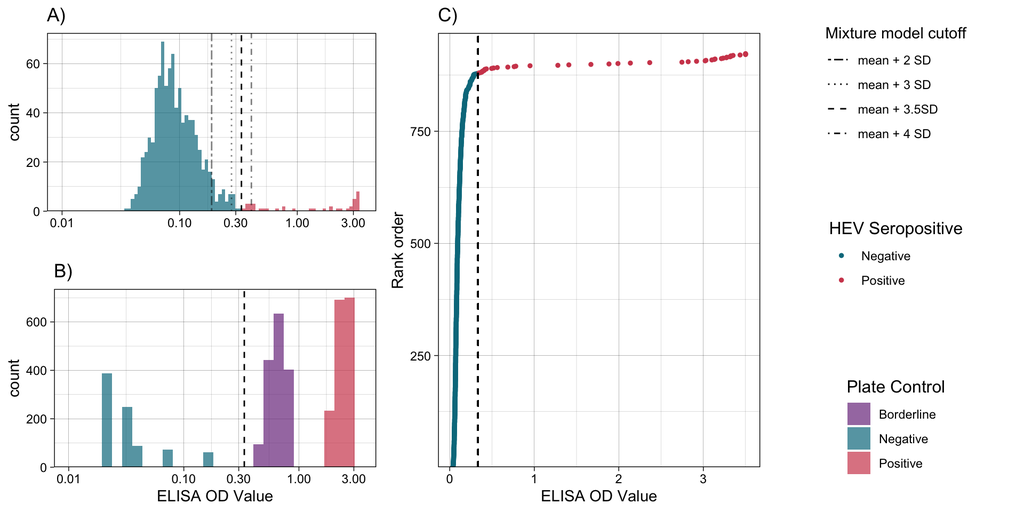

## Figure 2: Quantiative antibody responses by date and study site location

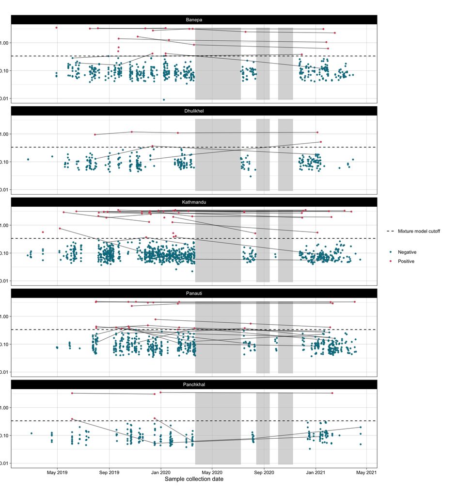

## Table 2: HEV Seroprevalence at baseline visit

levels

N()

N seropositive

Crude seroprevalence

Modeled seroprevalence (95% CI)

p value

Overall

923

44

4.8%

**Age, categorical**

0-<5

199

2

1.0%

1.0% (0.3-3.9)

5-<10

204

2

1.0%

1.0% (0.2-3.8)

0.980

10-<15

223

7

3.1%

3.1% (1.5-6.4)

0.151

15-25

297

33

11.1%

11.1% (8.0-15.2)

0.001

**City/town***

Banepa

167

10

6.0%

3.6% (1.7-7.4)

Ref

Dhulikhel

85

1

1.2%

0.7% (0.1-5.3)

0.134

Kathmandu

401

19

4.7%

2.3% (1.3-4.2)

0.281

Panauti

197

10

5.1%

2.8% (1.3-5.7)

0.583

Panchkhal

73

4

5.5%

3.6% (1.3-9.9)

0.986

**Gender***

Female

431

19

4.4%

2.4% (1.3-4.3)

Ref

Male

482

24

5.0%

2.7% (1.6-4.7)

0.718

**Household monthly income, Nepalese rupees***

<30000

412

10

2.4%

1.4% (0.7-3.0)

Ref

>30000

332

26

7.8%

4.4% (2.5-7.5)

0.003

**Primary water source***

Municipal

326

11

3.4%

2.0% (1.0-3.9)

Ref

Bottled

246

17

6.9%

3.6% (1.9-6.7)

0.121

Ground

129

5

3.9%

2.3% (0.9-5.9)

0.763

Private

40

1

2.5%

0.8% (0.1-6.3)

0.424

Surface

171

9

5.3%

3.0% (1.4-6.3)

0.373

**Household treats drinking water***

No

472

18

3.8%

2.2% (1.2-3.9)

Ref

Yes

440

25

5.7%

3.0% (1.8-5.2)

0.289

Note:

*Mixed effect models adjusted for age with a random effect for city/town

## Figure 3: Age-dependent Seroprevalence

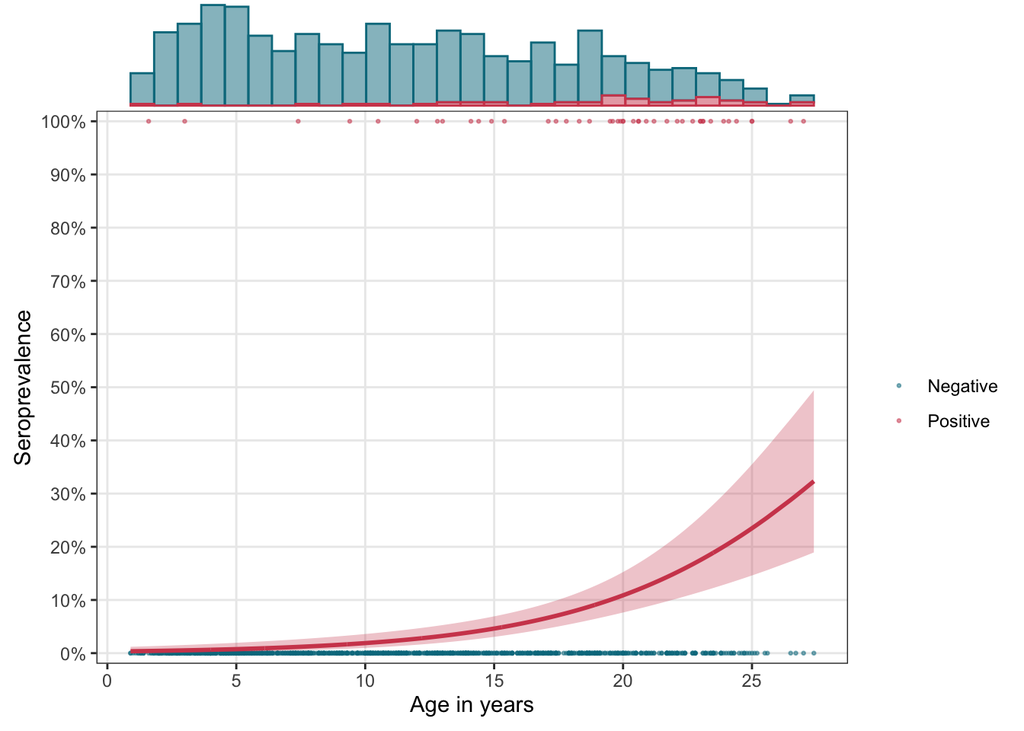

## Table 3: HEV Seroincidence

Seroincidence rate per 1000 person-years

Incident seroconversions

Person-years

Seroconversions/person-time

Modeled seroincidence*

p-value*

Overall

9

822.8

10.9 (5.0-20.8)

1.2 (0.6-2.3)

**Age, categorical**

0-<5

0

115.2

0.0 (0.0-32.0)

0.00 (0.00-0.00)

5-<10

2

222.7

9.0 (1.1-32.4)

1.03 (0.26-4.10)

Ref

10-<15

3

214.7

14.0 (2.9-40.8)

1.58 (0.51-4.90)

0.007

15-25

4

270.2

14.8 (4.0-37.9)

1.53 (0.58-4.09)

0.007

**City/town***

Banepa

2

170.5

11.7 (1.4-42.4)

1.2 (0.3-5.0)

Ref

Dhulikhel

2

106.9

18.7 (2.3-67.6)

2.0 (0.5-8.1)

0.624

Kathmandu

1

247.6

4.0 (0.1-22.5)

0.4 (0.1-2.9)

0.355

Panauti

4

208.9

19.1 (5.2-49.0)

2.0 (0.7-5.4)

0.586

Panchkhal

0

89.0

0.0 (0.0-41.4)

1.000

**Gender***

Female

4

389.8

10.3 (2.8-26.3)

1.1 (0.4-2.9)

Ref

Male

5

429.4

11.6 (3.8-27.2)

1.2 (0.5-3.0)

0.832

**Household monthly income, Nepalese rupees***

<30000

3

381.6

7.9 (1.6-23.0)

0.0 (0.0-0.2)

Ref

>30000

3

283.5

10.6 (2.2-30.9)

0.0 (0.0-0.2)

0.913

**Primary water source***

Municipal

2

320.7

6.2 (0.8-22.5)

0.7 (0.2-2.7)

Ref

Bottled

1

157.7

6.3 (0.2-35.3)

0.6 (0.1-4.5)

0.958

Ground

1

138.0

7.2 (0.2-40.4)

0.8 (0.1-5.5)

0.903

Private

0

26.1

0.0 (0.0-141.3)

1.000

Surface

5

176.7

28.3 (9.2-66.0)

2.9 (1.2-7.3)

0.076

**Household treats drinking water***

No

5

442.4

11.3 (3.7-26.4)

1.2 (0.5-2.9)

Ref

Yes

4

376.8

10.6 (2.9-27.2)

1.1 (0.4-3.0)

0.881

Note:

*Mixed effect poisson model adjusted for age and repeated measures

```
##
##     Municipal Bottled Ground Private Surface
##   0        92       0    167       0     287
##   1         0       0      1       0       3
```

# Maps moved to map .R file

## Supplemental Table 1: Sensitivity analysis of seroprevalence and seroincidence rate to different cutoff values

| Cutoff | Baseline N seropositive | Baseline Total N | Baseline Seroprevalence | Overall Incident Cases | Overall Person-years | Overall Seroincidence rate per 1000 PYs |
| --- | --- | --- | --- | --- | --- | --- |
| +2 SD | 97 | 923 | 10.5% | 61 | 800.2 | 76.23 |
| +3 SD | 53 | 923 | 5.7% | 15 | 817.2 | 18.34 |
| +4 SD | 38 | 923 | 4.1% | 4 | 825.3 | 4.84 |

## Supplemental Table 2: Seroreversions by age category

|  | Seroreversions | Person-years | Seroreversion rate per 1000 person-years |
| --- | --- | --- | --- |
| **Overall** |  |  |  |
| Overall | 15 | 37.47 | 400.4 (224.1-660.3) |
| **Age, categorical** |  |  |  |
| 0-<5 | 1 | 0.49 | 2027.8 (51.3-11298.1) |
| 5-<10 | 3 | 1.38 | 2174.8 (448.5-6355.6) |
| 10-<15 | 5 | 4.34 | 1152.9 (374.3-2690.4) |
| 15-25 | 6 | 31.26 | 192.0 (70.4-417.8) |

## Supplemental Table 3: Seroincidence derived from the age-dependent seroprevalence

[output not shown]